# Project Report Draft 5

Vivian Zheng, Tyler Braito, Calvin Aberg, Mattia Saladini, and Ndidi Nwosu

2022-11-10

## Plots on City Bike Data in Washington DC

1. Scatterplot of Ride Duration by Date

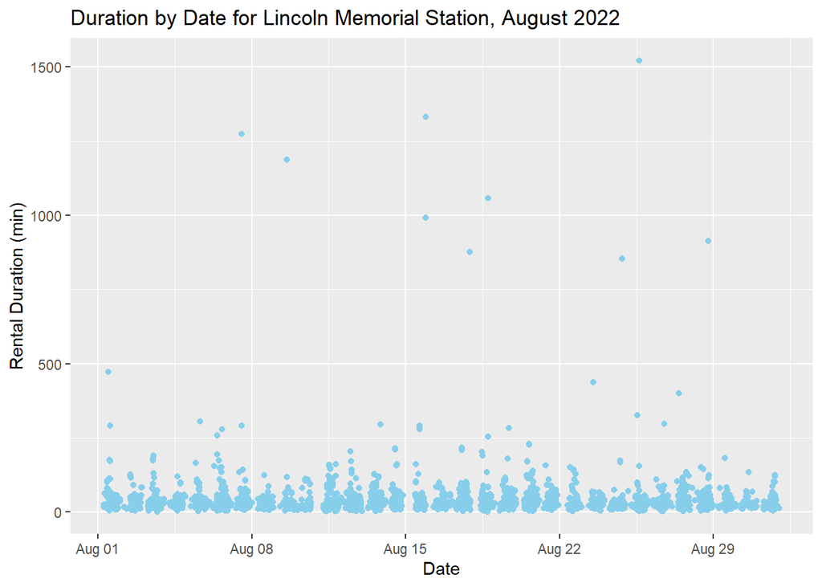

This scatter plot shows the rental duration differences between dates throughout the month of August. Most of the rentals are clustered under 60 minutes, with a few outliers above 1000 minutes. These outliers may reflect errors in the tracking system of the bike, or instances when users forgot to return their bikes to another station. There seems to be a pretty uniform distribution of rentals by date throughout the month.

2. Daily Usage Rank of the Top 10 Most Common Starting Stations

```
## [1] 10
```

```
## [1] 10
```

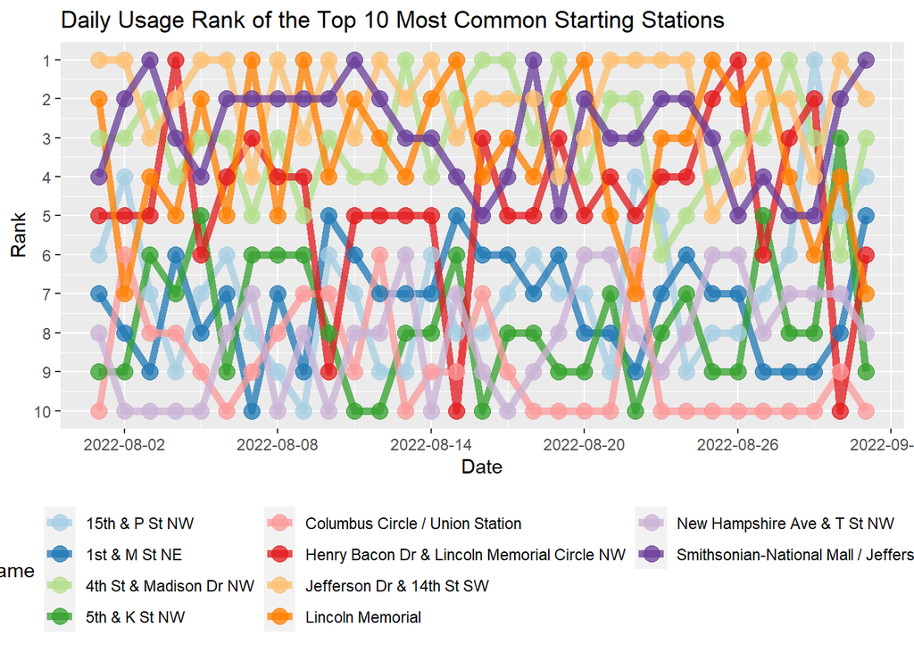

This plot is visualizing the usage ranks of the 10 most common starting of August for each day of the month. From the plot, we can see that generally the top 4 stations at the very start of the month remained in the top five ranks for most of the rest of the month. Conversely, it was rather rare for a station that initially ranked below the top 5 to reach a top five rank. The red line that was exactly ranked #5 at the beginning exhibits the widest range of ranks for the rest of the month. From this we can conclude that the very most popular stations will consistently draw the most demand from day-to-day, even if their individual ranks within these top few spots will fluctuate.

3. Density Plot of Riding Distance by Bike Type

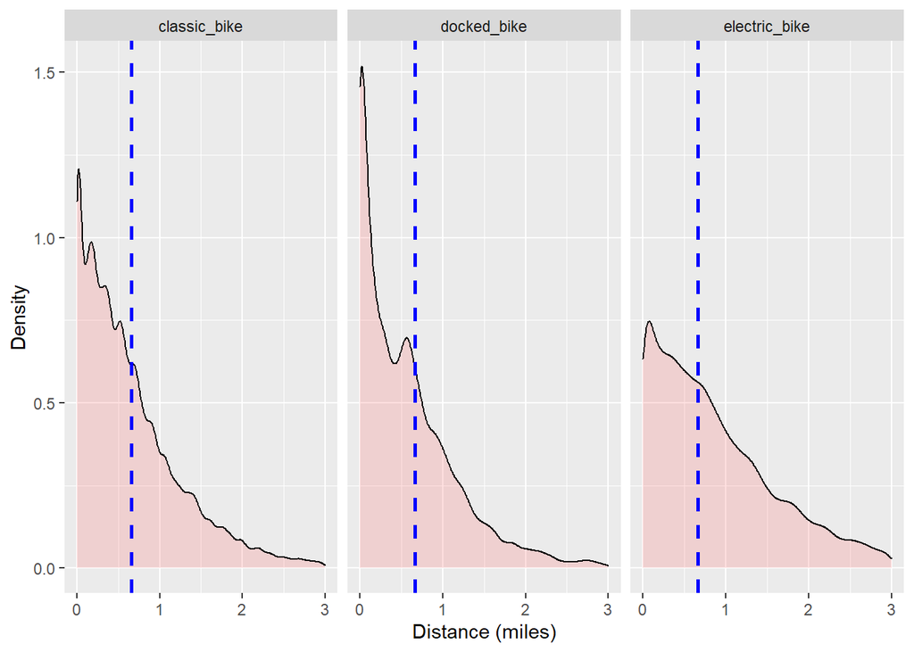

In this plot, we are visualizing the differences in riding distance by type of rideable bike. To do this, we can see three separate density plots of each rideable type of bike that Capital Bikes offers. This visualization gives us a great deal of information of the tendencies of the users of each bike type. With the docked bike, there is a very large concentration of riders riding very short distances and stopping. However, with the electric bikes, there is a much larger skew of riders riding much longer distances. These tendencies can give us insight into which bike types are preferable in different locations, and how users are likely to use different bikes.

4. Barplots of Distance Ridden by Type of Bike

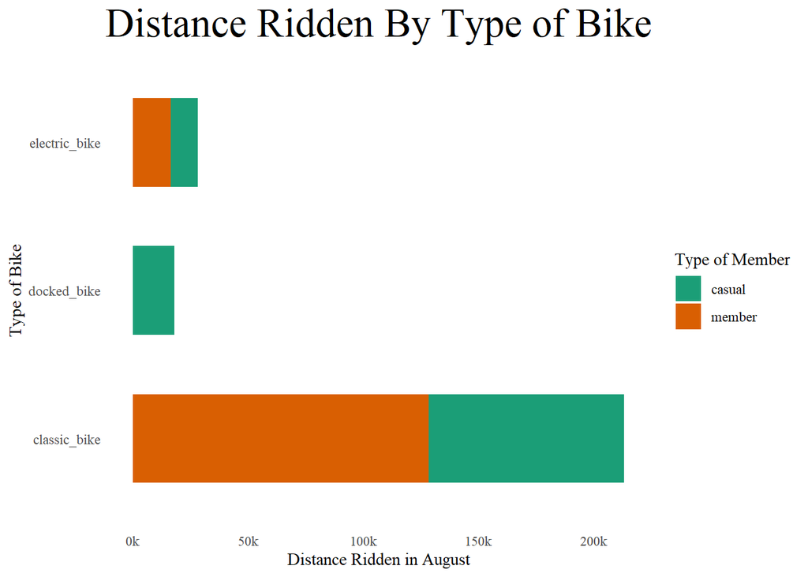

This plot illustrates the distance ridden on different types of bikes colored by whether the rider was a member of Capital Bikes or just a casual rider. From a business perspective, this plot is very helpful in illustrating the tendencies of different customers and how they use Capital Bikes’ products. With this, we can see that the bulk of the usage of the bikes are centered on classic bikes with the majority of member distance being on the classic bikes. However, the docked bike has seen very little usage by member customers. The reasons for this disparity could be a question to be examined by those with a stake in the business’ success.

5. Boxplots of Bike Types and Rental Durations

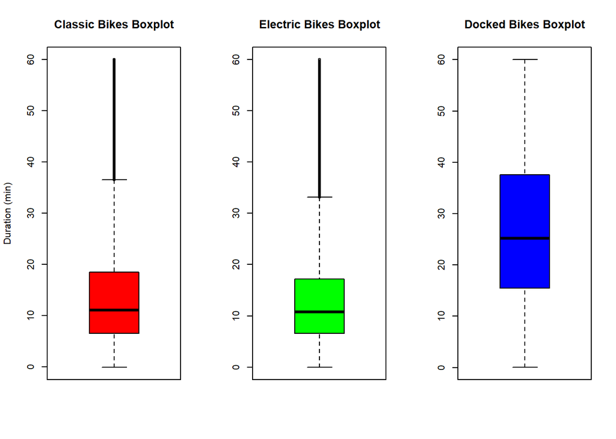

The first dataset describes different characteristics (duration, location, etc.) of each bike rental ride in the DC Area. The three box plots each display the minimum, first quartile, median, third quartile, and maximum bike rental durations for Classic, Electric, and Docked bikes separately.

6. Most Popular Stations by Start and End Location

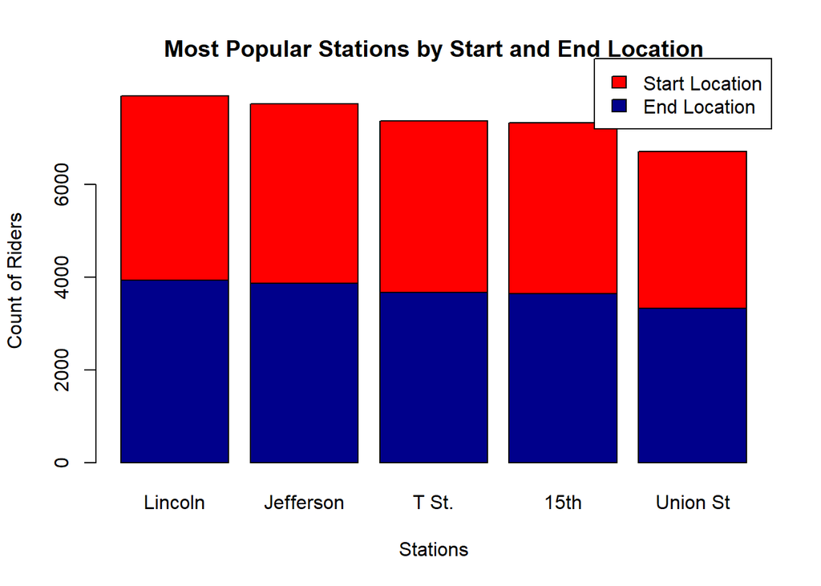

This plot describes the most popular starting stations and ending stations for Capital Bike riders in August. The total height of the bar is the sum of trips started and ended at a given station, with the blue being the number of trips ended and red being the number of trips started. These five stations were the most commonly visited stations in the Washington D.C. area. We can see that there isn’t a majority station within the data, and, within the top five stations, there is a fairly balanced flow in and out of each station.

7. Histogram of Usage Frequency by Days of the Week and Date

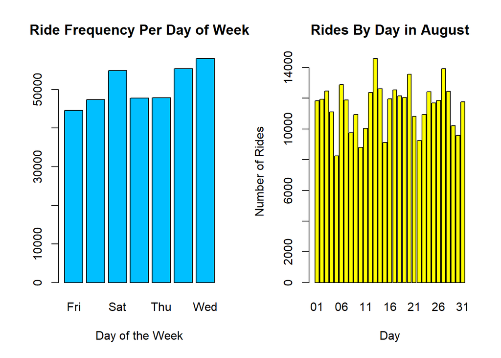

8. Temperature in DC in August 2022 with Average Temp based on Weather Condition

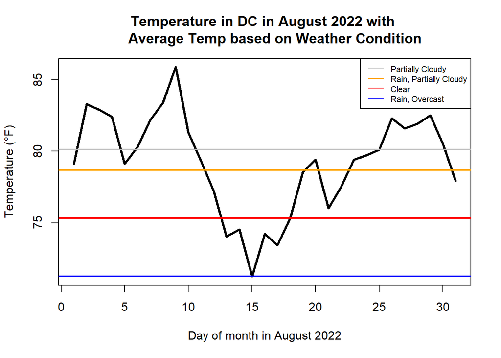

9. Bike Rides vs Average Temperature of That Day

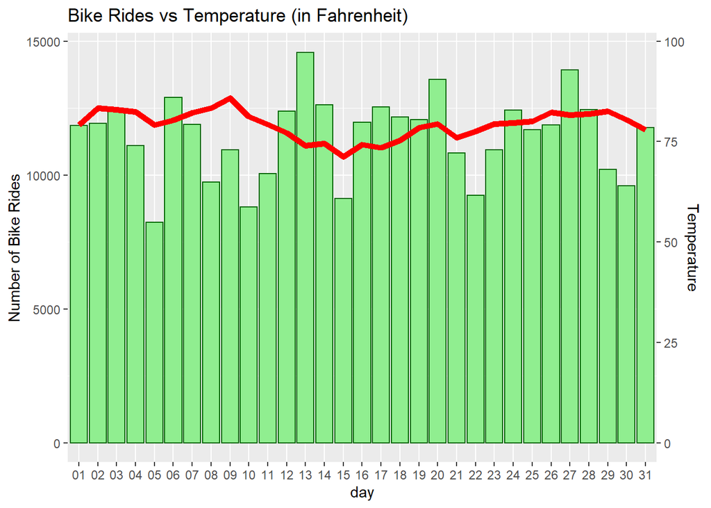

This graph directly compares the temperature of the day (represented by the red line) to the number of bike rides that were taken on city bikes that day. As the graph shows, there seems to be some correlation. When the temperature dipped around the 12th of the month, there was an increase in bike rides, likely due to the fact that people may prefer to bike in slightly cooler weather. But on the 15th, the coolest day of the month, there was a sudden decrease in bike rides, which makes sense because as seen in graph number 8, that was a rainy day. Bike rides seem to relatively correlate with temperature, but precipitation also seems to play a role.

10. Concentration of Trip Starts

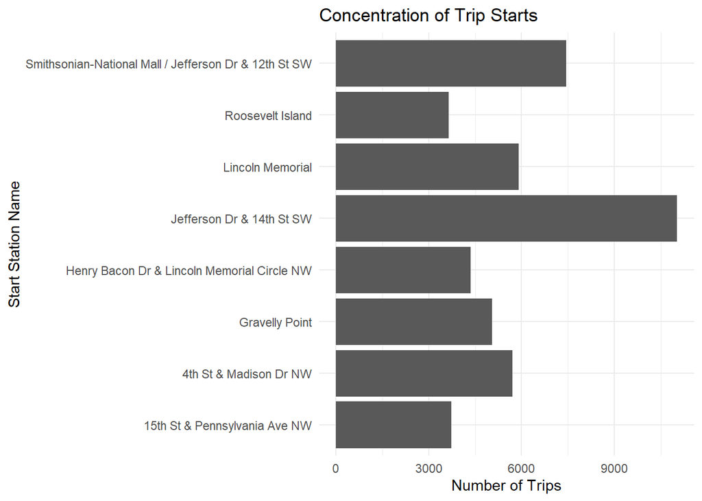

This graph shows the number of trips that start from a select number of stations. As the graph shows, there seems to be a high concentration of bike rides that start from Jefferson Dr & 14th St SW, which this station having the most bike rides by a large margin. Meanwhile, the least popular starting station seems to be Roosevelt Island. Jefferson Dr & 14th St SW may be a popular station where there is a higher concentration of bike riders, so investing in more bikes at this station, or creating more bike stations near this area may be a profitable move for this Bike Share company, while investing less in places near Roosevelt Island may not be.

11. Effects of Afternoon Rain on Bike Usage

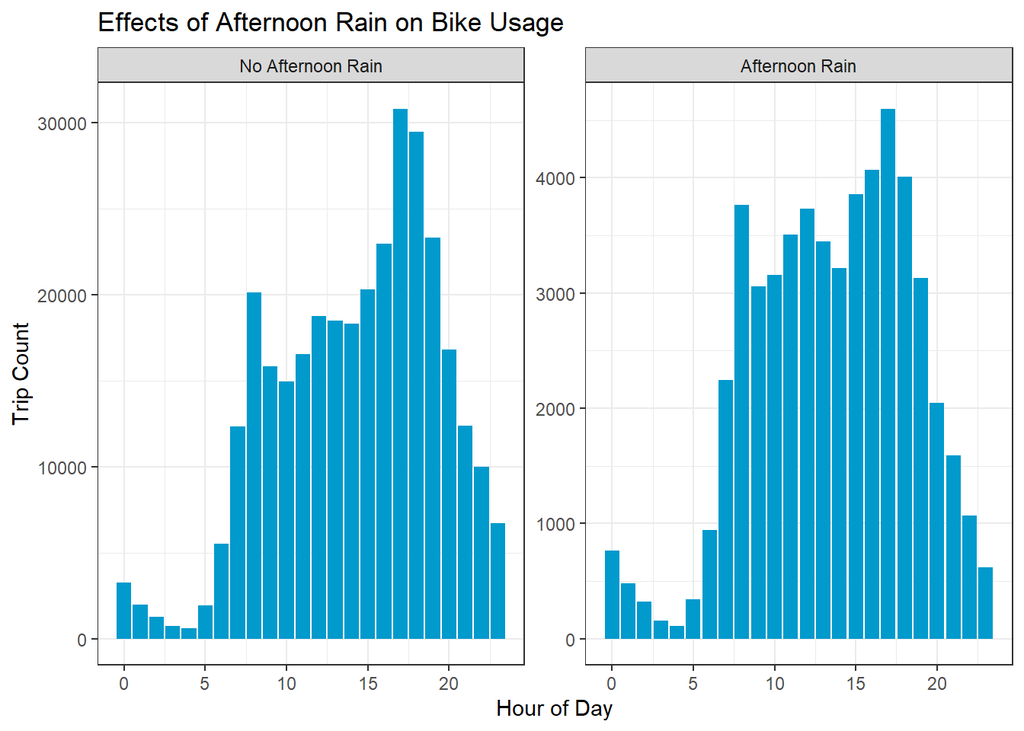

This graph shows how the presence of afternoon rain will affect the distribution of bike usage throughout the day. When there is no Afternoon rain, there is usually a sharp spike in usage around 5-6pm. When there is rain, however, the hours from 7am-6pm see more even usage levels. The shape of the beginning or end of the day is still not effected very much.

12. Effects of Weather Description on Bike Rides

```
##
## Call:
## lm(formula = total_rides ~ rain + clear + cloudy, data = ride_weather)
##
## Residuals:
##      Min       1Q   Median       3Q      Max
## -2630.78  -616.12   -70.12   555.25  2406.22
##
## Coefficients:
##             Estimate Std. Error t value Pr(>|t|)
## (Intercept)  12527.3     1358.0   9.225 7.78e-10 ***
## rain1        -2338.3      517.5  -4.518 0.000111 ***
## clear1        -379.1     1496.0  -0.253 0.801882
## cloudy1       -292.2     1323.4  -0.221 0.826899
## ---
## Signif. codes:  0 '***' 0.001 '**' 0.01 '*' 0.05 '.' 0.1 ' ' 1
##
## Residual standard error: 1255 on 27 degrees of freedom
## Multiple R-squared:  0.4562, Adjusted R-squared:  0.3958
## F-statistic: 7.551 on 3 and 27 DF,  p-value: 0.0008018
```

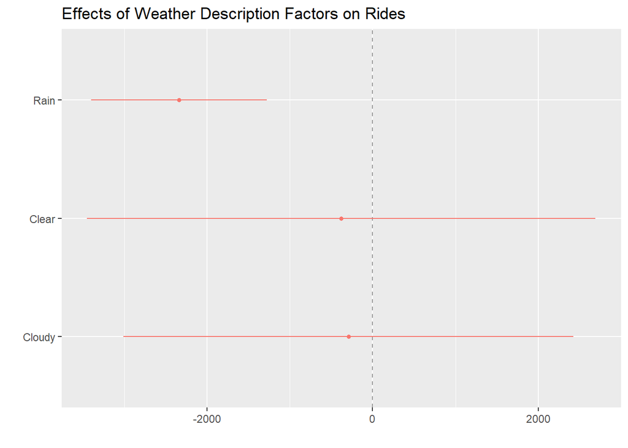

As seen from the various plots, there are various patterns that can be observed within this bike share data, such as the popularity of classic bikes, and the more frequent usage by member as opposed to causual riders. This information could be crucial to the Washington DC city bike share company, as they could maximze profits by focusing advertising on their membership plan, or investing more in classic bikes the most riders seem to enjoy riding more.